# Info 201 Midpoint Project Deliverable

AD5

May 15, 2019

## Introduction

As a group, we were interested in the various natural phenomena that occurs around us and decided to delve deeper into an environmental structure that currently has tremendous impact on us in Seattle, Washington, and that would be Mount Rainier. Some of us have taken/are currently taking a volcanos course and we believe this would be another way to learn more about this topic, as it can greatly affect our awareness of volcanic activity. We source our volcano data (from 1980 to 2019) from the [Significant Volcano Eruption Database](https://www.ngdc.noaa.gov/nndc/servlet/ShowDatasets?dataset=102557&search_look=50&display_look=50).

## Summary Table

The table hopes to explain “out of the eruptions with recorded VEI’s, what was the average for each year?” Also, what number of incidents per year did not have recorded incidents? All of this would be grouped by the year, allowing the viewer to see a volcano activity lull in some years prior. With the additional information of VEI not being recorded, these could turn to be interesting points of research to further our understanding.

| Year | Total Number of Incidents | Number of Incidents with Recorded VEI | Average VEI | Missing incidents |
| --- | --- | --- | --- | --- |
| 1980 | 3 | 2 | 4 | 1 |
| 1981 | 7 | 5 | 2.4 | 2 |
| 1982 | 4 | 4 | 4.75 | 0 |
| 1983 | 4 | 4 | 2.5 | 0 |
| 1984 | 4 | 2 | 3 | 2 |
| 1985 | 3 | 3 | 2.33333333333333 | 0 |
| 1986 | 5 | 4 | 2.5 | 1 |
| 1987 | 3 | 2 | 2.5 | 1 |
| 1988 | 5 | 4 | 3 | 1 |
| 1989 | 2 | 0 | Not Available | 2 |
| 1990 | 10 | 7 | 2.71428571428571 | 3 |
| 1991 | 7 | 6 | 2.83333333333333 | 1 |
| 1992 | 8 | 7 | 2.28571428571429 | 1 |
| 1993 | 9 | 6 | 1.33333333333333 | 3 |
| 1994 | 7 | 6 | 2.66666666666667 | 1 |
| 1995 | 6 | 4 | 2.25 | 2 |
| 1996 | 6 | 5 | 2.6 | 1 |
| 1997 | 9 | 5 | 2.4 | 4 |
| 1998 | 3 | 0 | Not Available | 3 |
| 1999 | 5 | 5 | 3 | 0 |
| 2000 | 5 | 4 | 2.5 | 1 |
| 2001 | 4 | 4 | 2.25 | 0 |
| 2002 | 6 | 5 | 2.8 | 1 |
| 2003 | 1 | 1 | 3 | 0 |
| 2004 | 3 | 3 | 2.33333333333333 | 0 |
| 2005 | 3 | 2 | 3.5 | 1 |
| 2006 | 7 | 6 | 2 | 1 |
| 2007 | 4 | 1 | 4 | 3 |
| 2008 | 4 | 2 | 3 | 2 |
| 2009 | 2 | 0 | Not Available | 2 |
| 2010 | 9 | 5 | 2.4 | 4 |
| 2011 | 10 | 5 | 3.2 | 5 |
| 2012 | 3 | 0 | Not Available | 3 |
| 2013 | 8 | 2 | 2.5 | 6 |
| 2014 | 6 | 1 | 3 | 5 |
| 2015 | 6 | 1 | 2 | 5 |
| 2016 | 5 | 0 | Not Available | 5 |
| 2017 | 8 | 2 | 2 | 6 |
| 2018 | 14 | 8 | 2 | 6 |
| 2019 | 2 | 1 | 4 | 1 |

## Chart One

#### Volcanic Eruption Zones

[interactive chart not shown]

The purpose of this map is to show the locations of recent eruptions since 1980. With this, people with a brief understanding of tectonic plates would be able to understand and see the correlation between earthquakes, eruptions and plate boundaries. Even without this prior knowledge, the map can also provide locations where imminent danger could be a possibility, which is a step towards answering our question regarding volcanic danger in certain areas. Looking at the map, we can see a concentration of volcanic activity among the continental and oceanic crusts, forming the famous Ring of Fire.

## Chart Two

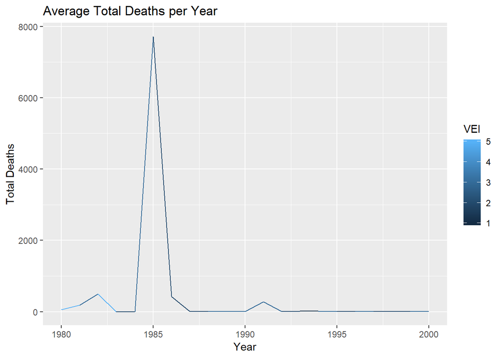

## Chart Three

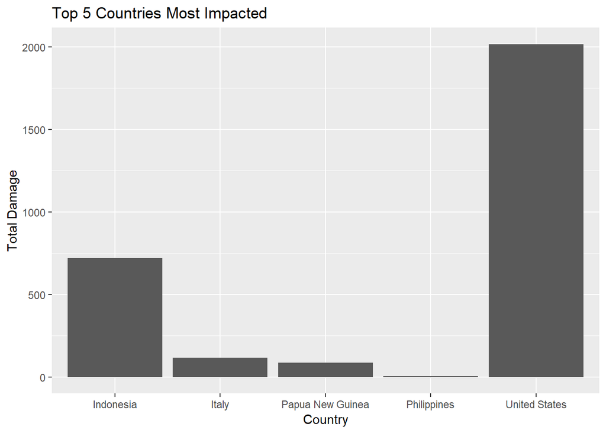

The purpose of this barplot is to compare the severity of the top 5 countries impacted in terms of damage to their environment and living conditions since 1980. This will allow us to see the most dangerous areas and give us a better understanding of the locations to observe when looking to answer our question about how we can predict hazard zones. In this plot we can see that the United States has suffered the most damage in the past 40 years compared to the other top 4 countries in terms of monetary damage taken. This was most likely due to Mount Saint Helens; given it’s proximity to us, gives our group a reason to find ways to map out hazardous areas through our given data.